# titanic_investigate

## Titanic Investigate Analysis

This is a project I use pandas and matplotlib to explore the Kaggle Titanic dataset.

There are 3 steps:

- Load and clean data
- Summarize data and Questions
- Explore data and answer questions

### Step 1. Load and clean data

```python
import pandas as pd
import numpy as np
import matplotlib.pyplot as plt
import seaborn as sns

# Load data
titanic_data = pd.read_csv('titanic-data.csv')
titanic_data.head()
```

|  | PassengerId | Survived | Pclass | Name | Sex | Age | SibSp | Parch | Ticket | Fare | Cabin | Embarked |
| --- | --- | --- | --- | --- | --- | --- | --- | --- | --- | --- | --- | --- |
| 0 | 1 | 0 | 3 | Braund, Mr. Owen Harris | male | 22.0 | 1 | 0 | A/5 21171 | 7.2500 | NaN | S |
| 1 | 2 | 1 | 1 | Cumings, Mrs. John Bradley (Florence Briggs Th... | female | 38.0 | 1 | 0 | PC 17599 | 71.2833 | C85 | C |
| 2 | 3 | 1 | 3 | Heikkinen, Miss. Laina | female | 26.0 | 0 | 0 | STON/O2. 3101282 | 7.9250 | NaN | S |
| 3 | 4 | 1 | 1 | Futrelle, Mrs. Jacques Heath (Lily May Peel) | female | 35.0 | 1 | 0 | 113803 | 53.1000 | C123 | S |
| 4 | 5 | 0 | 3 | Allen, Mr. William Henry | male | 35.0 | 0 | 0 | 373450 | 8.0500 | NaN | S |

```python
titanic_data.shape
```

```
(891, 12)
```

There're 891 observations and 10 attributes might associate with whether a passenage survived or not during the tragedy.

```python
len(titanic_data)-titanic_data.count()
```

```
PassengerId      0
Survived         0
Pclass           0
Name             0
Sex              0
Age            177
SibSp            0
Parch            0
Ticket           0
Fare             0
Cabin          687
Embarked         2
dtype: int64
```

There are 3 columns involve missing values. Age, Cabin and Embarded. For 'Age', it's reasonable to replace age by the mean age here because this wouldn't make big influence on whole distribution.

```python
mean_age = titanic_data['Age'].mean()
titanic_data['Age'] = titanic_data['Age'].fillna(mean_age)
```

For 'Cabin', the missing value takes up to 80% and any replacement might significantly bias the result, so I will remove this column.

```python
titanic_data = titanic_data.drop('Cabin', axis=1)
```

For 'Embarded', here I drop the 2 rows with missing values:

```python
titanic_data = titanic_data.dropna()
# Beside, I will drop 'PassengerId' because it's meaningless
titanic_data = titanic_data.drop('PassengerId', axis=1)
# Now there's no missing data
len(titanic_data)-titanic_data.count()
```

```
Survived    0
Pclass      0
Name        0
Sex         0
Age         0
SibSp       0
Parch       0
Ticket      0
Fare        0
Embarked    0
dtype: int64
```

```python
# For future usage, I create a new column named age_group
# Below function return age range, for example, age 12 will be transformed into 10-20
def group_by_age(i):
    return str(int(i/10)*10)+'-'+str(int(i/10)*10+10)
titanic_data['Age_group'] = titanic_data['Age'].apply(group_by_age)
```

The reason I group the age is that, instead of considering all the age with so many discrete values we can see which range of age will have most impact on survival rate. I set interval as 10 not only because of better visualization, but also because of these age intervals could represent different target group. The classification is based on assumption:

- 0-10 represents children
- 10-20 represents teenages
- 20-30 represents youth who didn't have too much working/social experience, but were full of energy
- 30-40, 40-50, and 50-60 represents people who were more likely to have many years' working and social experience, also more likely to have children. But 3 levels were classfied because there could be difference which we can check later
- 60-70 and 70-80 or more were older people who might have grand children and their children might already be adults This grouping method is based on how I think about the people with different age. In order to know if this grouping strategy is good or not, more data (like their income, marriage, employment etc.) should be provided. Now we can just use these intervals as levels of factors and see if they are significantly correlated with survival rate.

Beside, in order to have better visualization, I set 'Sex' to use capital for first letter: 'Male' and 'Female':

```python
titanic_data['Sex'] = titanic_data.Sex.map({'female':'Female', 'male':'Male'})
```

And I would like to use 'Gender' instead of 'Sex' as variable name:

```python
titanic_data = titanic_data.rename(columns={'Sex':'Gender'})
```

Now we have data ready for analysis.

### Step 2: Summarize data and Questions

```python
titanic_data.head()
```

|  | Survived | Pclass | Name | Gender | Age | SibSp | Parch | Ticket | Fare | Embarked | Age_group |
| --- | --- | --- | --- | --- | --- | --- | --- | --- | --- | --- | --- |
| 0 | 0 | 3 | Braund, Mr. Owen Harris | Male | 22.0 | 1 | 0 | A/5 21171 | 7.2500 | S | 20-30 |
| 1 | 1 | 1 | Cumings, Mrs. John Bradley (Florence Briggs Th... | Female | 38.0 | 1 | 0 | PC 17599 | 71.2833 | C | 30-40 |
| 2 | 1 | 3 | Heikkinen, Miss. Laina | Female | 26.0 | 0 | 0 | STON/O2. 3101282 | 7.9250 | S | 20-30 |
| 3 | 1 | 1 | Futrelle, Mrs. Jacques Heath (Lily May Peel) | Female | 35.0 | 1 | 0 | 113803 | 53.1000 | S | 30-40 |
| 4 | 0 | 3 | Allen, Mr. William Henry | Male | 35.0 | 0 | 0 | 373450 | 8.0500 | S | 30-40 |

From the data, I have 3 questions to be answered:

- How demographic data distributed on the board and how are they distributed among different classes?
- Did females have bigger survival rate? Any difference of age between survived women and unsurvived women?
- Who were most likely to get bigger survival chance? (multi-variable analysis)

### Step 3: Investigate and answer the questions

#### 1. How demographic data distributed on the board and how are they distributed among different classes?

```python
titanic_data['Gender'].value_counts()
```

```
Male      577
Female    312
Name: Gender, dtype: int64
```

There was 577 males and 312 females, males took up over **64%**

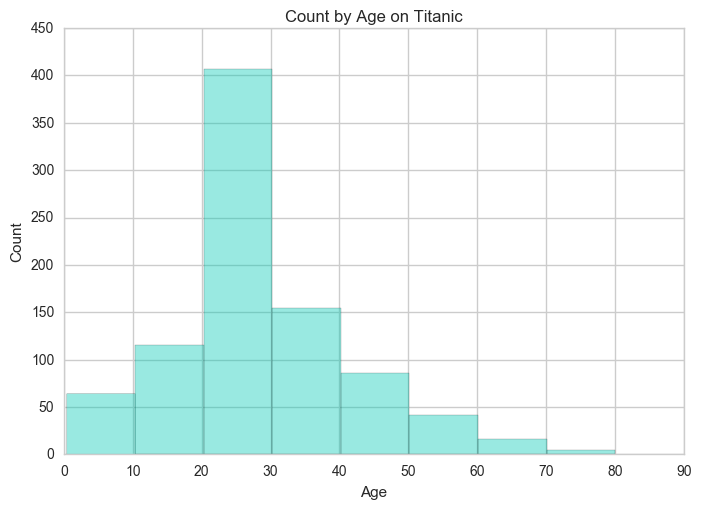

```python
sns.set_style("whitegrid")
sns.distplot(titanic_data['Age'], kde=False, color='#01cab4',bins=8)
plt.ylabel('Count')
plt.title('Count by Age on Titanic')
plt.show()
```

There are more people aging 20-30 than other.

Among class 1 (Top class), class 2 and class 3:

```python
# Number of people in different classes:
titanic_data['Pclass'].value_counts()
```

```
3    491
1    214
2    184
Name: Pclass, dtype: int64
```

```python
data_by_class = titanic_data.groupby('Pclass')
data_by_class.mean()
```

| Pclass | Survived | Age | SibSp | Parch | Fare |
| --- | --- | --- | --- | --- | --- |
| 1 | 0.626168 | 36.927073 | 0.420561 | 0.359813 | 84.193516 |
| 2 | 0.472826 | 29.866958 | 0.402174 | 0.380435 | 20.662183 |
| 3 | 0.242363 | 26.403259 | 0.615071 | 0.393075 | 13.675550 |

Some interesting conclusion can be drawn:

```python
data_by_class_gender = titanic_data.groupby(['Gender','Pclass'])['Survived'].apply(len).reset_index()
data_by_class_gender
```

|  | Gender | Pclass | Survived |
| --- | --- | --- | --- |
| 0 | Female | 1 | 92 |
| 1 | Female | 2 | 76 |
| 2 | Female | 3 | 144 |
| 3 | Male | 1 | 122 |
| 4 | Male | 2 | 108 |
| 5 | Male | 3 | 347 |

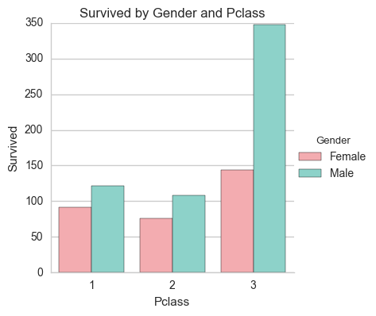

```python
colors = ['#ffa0a6','#82ddd2']

sns.factorplot(x="Pclass", y="Survived", hue="Gender", data=data_by_class_gender, kind="bar",\
              palette = colors)
plt.title('Survived by Gender and Pclass')
plt.show()
```

The males in class 3 took up most ratio of all passengers.

Now let's see in each class how gender distributed.

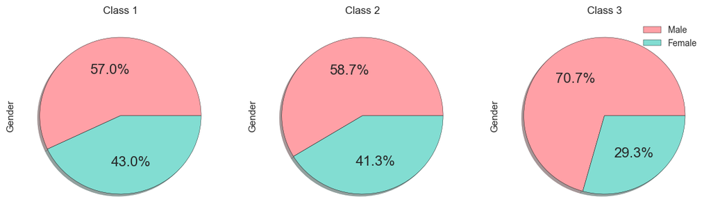

```python
data_class1 = titanic_data.loc[lambda df: df.Pclass == 1, :]
data_class2 = titanic_data.loc[lambda df: df.Pclass == 2, :]
data_class3 = titanic_data.loc[lambda df: df.Pclass == 3, :]

fig, axes = plt.subplots(nrows=1, ncols=3)
data_class1['Gender'].value_counts().plot(kind= 'pie', \
                                          title='Class 1', ax=axes[0], \
                                          figsize=(14, 4),autopct='%1.1f%%', \
                                          fontsize=16, shadow = True,\
                                          colors = colors, labels=None)

data_class2['Gender'].value_counts().plot(kind= 'pie', \
                                          title='Class 2', ax=axes[1], \
                                          figsize=(14, 4),autopct='%1.1f%%', \
                                          fontsize=16, shadow = True,\
                                          colors = colors, labels=None)

data_class3['Gender'].value_counts().plot(kind= 'pie', \
                                          title='Class 3', ax=axes[2], \
                                          figsize=(14, 4),autopct='%1.1f%%', \
                                          fontsize=16, shadow = True,\
                                          colors = colors,\
                                          legend=True, labels=None)
plt.show()
```

The ratio of males were significantly different. In class 1 and 2, it's arround 58%, but in class 3, males took up over 70.7%.

#### 2. Did females have bigger survival rate? Any difference of age between survived women and unsurvived women?

```python
data_by_Gender = titanic_data.groupby('Gender')['Survived'].mean().reset_index()
data_by_Gender
```

|  | Gender | Survived |
| --- | --- | --- |
| 0 | Female | 0.740385 |
| 1 | Male | 0.188908 |

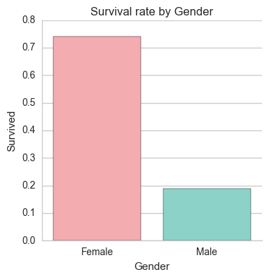

```python
sns.factorplot(x="Gender", y="Survived", data=data_by_Gender, kind="bar",\
              palette = colors)
plt.title('Survival rate by Gender')
plt.show()
```

Females (with survival rate over **74%**) were more likely to survive than males (with less than **19%** chance).

Now let's exam more details within women group, is there difference of age between survived women and unsurvived women?

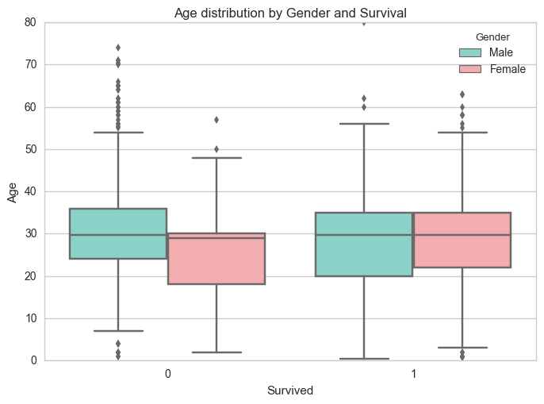

```python
survived_by_age_gender = titanic_data[['Gender','Survived','Age']]
sns.boxplot(x='Survived', y='Age', hue='Gender', data = survived_by_age_gender, palette=['#82ddd2','#ffa0a6'])
plt.title('Age distribution by Gender and Survival')
plt.show()
```

The ages of 4 groups are pretty close. So I pickup data of females and set up hypothesis to test if age is significant different of age between the groups: survived females and unsurvived females. Since this combination has the most difference from the plot and it's comparing similar individuals. The other combinations are similar.

Null hypothesis: $H_0$: $\mu_1 = \mu_2$, there's no difference with age between survived women and unsurvived women

$\mu_1$ is mean age of survived women $\mu_2$ is mean age of unsurvived women

```python
from scipy import stats

survived_female = titanic_data[(titanic_data.Survived == True) & (titanic_data.Gender =='Female')]
non_survived_female = titanic_data[(titanic_data.Survived == False) & (titanic_data.Gender =='Female')]

# Assume the individuals within each groups were independent
# because Titanic was huge and individuals might not have big chance to make influence on others
# And these 2 groups have different size, here I use independent t-test
stats.ttest_ind(survived_female['Age'], non_survived_female['Age'])
```

```
Ttest_indResult(statistic=1.6881197176366378, pvalue=0.09239394429827047)
```

As p-value > 0.05, there's no convincing evidence that there's big difference between women who survived and who didn't, and the 'Age' seems not a significant indicator for survival of women.

#### 3. Who were most likely to get bigger survival chance? (multi-variable analysis)

Most people will care about who would be most likely to survive in such accident. Let's look at gender, age and class and put together for analysis.

```python
survive_by_class_gender = titanic_data.groupby(['Pclass','Gender'],as_index=False)[['Survived']].mean()
```

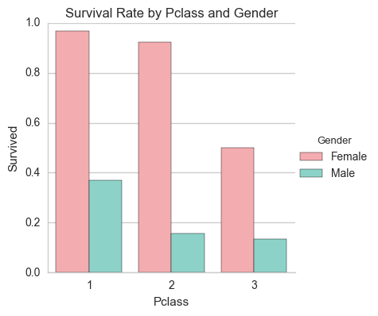

```python
sns.factorplot(x="Pclass", y="Survived", hue="Gender", data=survive_by_class_gender, kind="bar", palette=colors)
plt.title('Survival Rate by Pclass and Gender')
plt.show()
```

From above plot, we can see class1 had much higher survival rate than other 2 classes among male. However, for female, survival rate at class 1 and 2 are quite similar, though they both were larger than class 3.

Then let's exam by age:

```python
data_by_age = titanic_data.groupby(['Pclass','Age_group'],as_index=False)[['Survived']].mean()
data_by_age
```

|  | Pclass | Age_group | Survived |
| --- | --- | --- | --- |
| 0 | 1 | 0-10 | 0.666667 |
| 1 | 1 | 10-20 | 0.833333 |
| 2 | 1 | 20-30 | 0.593750 |
| 3 | 1 | 30-40 | 0.775510 |
| 4 | 1 | 40-50 | 0.594595 |
| 5 | 1 | 50-60 | 0.555556 |
| 6 | 1 | 60-70 | 0.250000 |
| 7 | 1 | 70-80 | 0.000000 |
| 8 | 1 | 80-90 | 1.000000 |
| 9 | 2 | 0-10 | 1.000000 |
| 10 | 2 | 10-20 | 0.500000 |
| 11 | 2 | 20-30 | 0.406250 |
| 12 | 2 | 30-40 | 0.395833 |
| 13 | 2 | 40-50 | 0.555556 |
| 14 | 2 | 50-60 | 0.333333 |
| 15 | 2 | 60-70 | 0.333333 |
| 16 | 2 | 70-80 | 0.000000 |
| 17 | 3 | 0-10 | 0.452381 |
| 18 | 3 | 10-20 | 0.257576 |
| 19 | 3 | 20-30 | 0.241636 |
| 20 | 3 | 30-40 | 0.217391 |
| 21 | 3 | 40-50 | 0.058824 |
| 22 | 3 | 50-60 | 0.000000 |
| 23 | 3 | 60-70 | 0.333333 |
| 24 | 3 | 70-80 | 0.000000 |

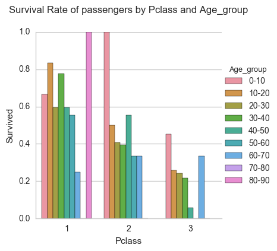

```python
sns.factorplot(x="Pclass", y="Survived", hue="Age_group", data=data_by_age, kind="bar")
plt.title('Survival Rate of passengers by Pclass and Age_group',y=1.08) #y is position of title
plt.show()
```

People aging 80-90 in class1 and 0-10 in class2 got highest survival rate both 100%, then in class1, people aging 0-20 and 30-40 got highest survival rate. Now check all categorical facotrs together:

```python
attributes = ['Pclass','Gender','SibSp','Parch','Age_group']
mean_survive_all_class = titanic_data.groupby(attributes)[['Survived']].mean()
```

To be careful, let's check count for each cell:

```python
count_survive_all_class = titanic_data.groupby(attributes)[['Survived']].count()
```

Then I will remove rows with count less than 10 in count_survive_all_class:

```python
merged_all = mean_survive_all_class.merge(count_survive_all_class, how='inner', left_index=True, right_index=True)
```

```python
merged_all = merged_all[(merged_all.Survived_y >= 10) & (merged_all.Survived_x >= 0.5)]
merged_all.sort_values(by='Survived_x', ascending=False)
```

| Pclass | Gender | SibSp | Parch | Age_group | Survived_x | Survived_y |
| --- | --- | --- | --- | --- | --- | --- |
| 1 | Female | 0 | 0 | 20-30 | 1.000000 | 10 |
|  |  |  |  | 30-40 | 1.000000 | 11 |
| 2 | Female | 0 | 0 | 20-30 | 0.909091 | 11 |
|  |  |  |  | 30-40 | 0.900000 | 10 |
| 3 | Female | 0 | 0 | 10-20 | 0.666667 | 12 |
|  |  |  |  | 20-30 | 0.641026 | 39 |
| 1 | Male | 0 | 0 | 30-40 | 0.538462 | 13 |
| 3 | Female | 1 | 0 | 20-30 | 0.538462 | 13 |

Therefore, these people were associated with high survival rate:

- class1, female, 20-40, no siblings or parents or children
- class2, female, 20-40, no siblings or parents or children
- class3, female, 10-30, no siblings or parents or children

### Conclusion

From the above analysis, we can see:

1. Passengers in class 1 were 7 years older than in class2 and 10 years older than class3. Males took up 64% of all the passengers, and males in class 3 took up most ratio (over 39%) of all passengers. Class 3 had 12% more male by percentage than class 1 and class 2
2. Females were indeed associated with bigger survival rate
3. Females aging between 20-40 in class 1 and 2 were associated with larger survival rate

However, there are several points we should pay attention to:

1. This is an explorative analysis, all the conclusions are association instead of causal relation
2. There are some assumptions in this analysis which might weaken the conclusion. For example, t-test requires normality used to determine if average ages were different between survived group and unsurvived group and advanced test is needed
3. There are more ways to dig out more information and make the survival rate more accurate, for example, we haven't use the 'Name' and 'Ticket' column. From the data, we can get inspired that if someone had name with 'Dr.' could have more chance to survive
4. If there're more data like income, employment status and marriage status, we can make further analysis and find more contributors associated with their survival rate